# Dimensionality reduction techniques

In this exercise, dimensionality reduction techniques are used to find components and connections in two different datasets and in that way reduce number of dimensions in them.

## Principal component analysis (PCA)

### Data

The “human” dataset contains different indicators of human development and gender inequality. In the modified dataset used in the PCA exercise, there are 155 observations (countries) and the following 8 variables:

“eduratio”: famale/male ratio of population with secondary education

“labourratio”: female/male ratio of labour force participation

“life”: life expectancy at birth

“expedu”: expected years of education

“gni”: gross national income (GNI) per capita

“matmort”: maternal mortality ratio

“adobirth”: adolescent birth rate

“parliament”: % of seats in parliament held by women

The summaries of the variables are displayed in the matrix below, and the plot below visualizes the distributions of the variables and displays the correlations between them. There are some rather big and quite obvious positive/negative correlations between some of the variables; for example, life expectancy correlates negatively with maternal mortality whereas expected years of education has a positive correlation with it.

```r
summary(human)
```

```
##     eduratio       labourratio          life           expedu
##  Min.   :0.1717   Min.   :0.1857   Min.   :49.00   Min.   : 5.40
##  1st Qu.:0.7264   1st Qu.:0.5984   1st Qu.:66.30   1st Qu.:11.25
##  Median :0.9375   Median :0.7535   Median :74.20   Median :13.50
##  Mean   :0.8529   Mean   :0.7074   Mean   :71.65   Mean   :13.18
##  3rd Qu.:0.9968   3rd Qu.:0.8535   3rd Qu.:77.25   3rd Qu.:15.20
##  Max.   :1.4967   Max.   :1.0380   Max.   :83.50   Max.   :20.20
##       gni            matmort          adobirth        parliament
##  Min.   :   581   Min.   :   1.0   Min.   :  0.60   Min.   : 0.00
##  1st Qu.:  4198   1st Qu.:  11.5   1st Qu.: 12.65   1st Qu.:12.40
##  Median : 12040   Median :  49.0   Median : 33.60   Median :19.30
##  Mean   : 17628   Mean   : 149.1   Mean   : 47.16   Mean   :20.91
##  3rd Qu.: 24512   3rd Qu.: 190.0   3rd Qu.: 71.95   3rd Qu.:27.95
##  Max.   :123124   Max.   :1100.0   Max.   :204.80   Max.   :57.50
```

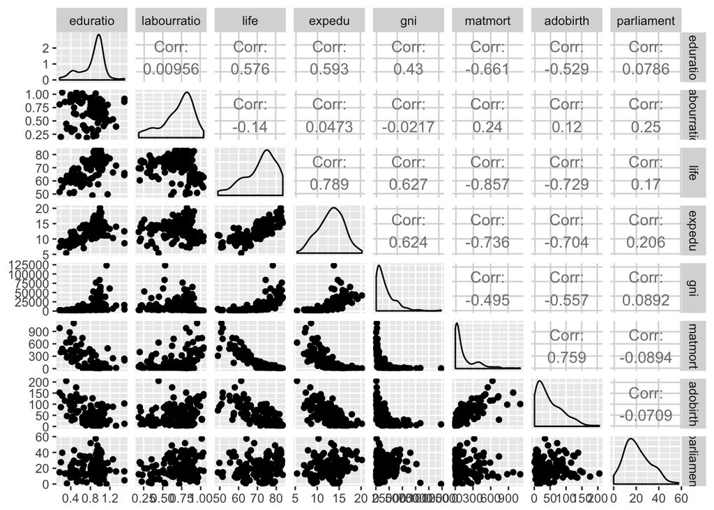

```r
ggpairs(human)
```

### Analysis

*Non-standardized data*

At first, principal component analysis is run on the non-standardized data. The results of the analysis can be seen below.

```r
pca_human <- prcomp(human)
pca_human
```

```
## Standard deviations:
## [1] 1.854416e+04 1.855219e+02 2.518701e+01 1.145441e+01 3.766241e+00
## [6] 1.565912e+00 1.912052e-01 1.591112e-01
##
## Rotation:
##                       PC1           PC2           PC3           PC4
## eduratio    -5.607472e-06  0.0006713951 -3.412027e-05 -2.736326e-04
## labourratio  2.331945e-07 -0.0002819357  5.302884e-04 -4.692578e-03
## life        -2.815823e-04  0.0283150248  1.294971e-02 -6.752684e-02
## expedu      -9.562910e-05  0.0075529759  1.427664e-02 -3.313505e-02
## gni         -9.999832e-01 -0.0057723054 -5.156742e-04  4.932889e-05
## matmort      5.655734e-03 -0.9916320120  1.260302e-01 -6.100534e-03
## adobirth     1.233961e-03 -0.1255502723 -9.918113e-01  5.301595e-03
## parliament  -5.526460e-05  0.0032317269 -7.398331e-03 -9.971232e-01
##                       PC5           PC6           PC7           PC8
## eduratio    -0.0022935252  2.180183e-02  6.998623e-01  7.139410e-01
## labourratio  0.0022190154  3.264423e-02  7.132267e-01 -7.001533e-01
## life         0.9865644425 -1.453515e-01  5.380452e-03  2.281723e-03
## expedu       0.1431180282  9.882477e-01 -3.826887e-02  7.776451e-03
## gni         -0.0001135863 -2.711698e-05 -8.075191e-07 -1.176762e-06
## matmort      0.0266373214  1.695203e-03  1.355518e-04  8.371934e-04
## adobirth     0.0188618600  1.273198e-02 -8.641234e-05 -1.707885e-04
## parliament  -0.0716401914 -2.309896e-02 -2.642548e-03  2.680113e-03
```

```r
s <- summary(pca_human)
pca_pr <- round(100*s$importance[2, ], digits = 1)



paste0(names(pca_pr), " (", pca_pr, "%)")
```

```
## [1] "PC1 (100%)" "PC2 (0%)"   "PC3 (0%)"   "PC4 (0%)"   "PC5 (0%)"
## [6] "PC6 (0%)"   "PC7 (0%)"   "PC8 (0%)"
```

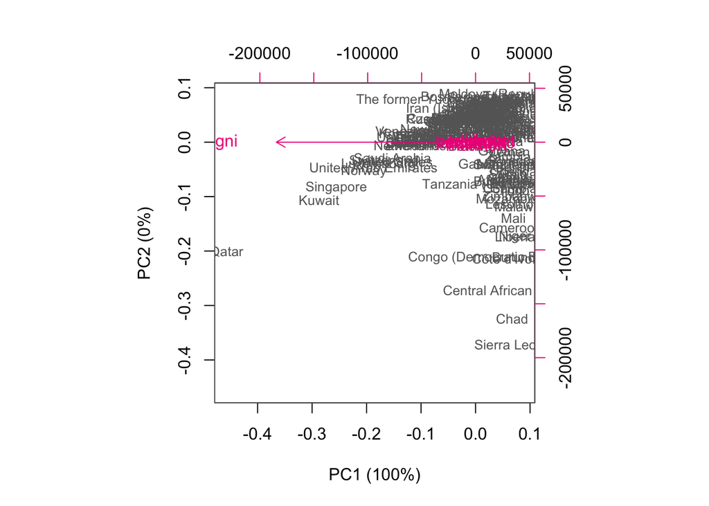

```r
pc_lab <-paste0(names(pca_pr), " (", pca_pr, "%)")
biplot(pca_human, cex = c(0.8, 1), col = c("grey40", "deeppink2"), xlab = pc_lab[1], ylab = pc_lab[2])
```

The first component (PC1) that is highly impacted by gross national income (GNI) per capita captures all the variance in the data when PCA is run using non-standardized data. So, the results can be interpreted as GNI explaining all the differences in human development and gender inequality between countries.

*Standardized data*

As PCA gives more importance to variables with large variance, the data is standardized to run PCA again in order to get more plausible results.

```r
human_std <- scale(human)
summary(human_std)
```

```
##     eduratio        labourratio           life             expedu
##  Min.   :-2.8189   Min.   :-2.6247   Min.   :-2.7188   Min.   :-2.7378
##  1st Qu.:-0.5233   1st Qu.:-0.5484   1st Qu.:-0.6425   1st Qu.:-0.6782
##  Median : 0.3503   Median : 0.2316   Median : 0.3056   Median : 0.1140
##  Mean   : 0.0000   Mean   : 0.0000   Mean   : 0.0000   Mean   : 0.0000
##  3rd Qu.: 0.5958   3rd Qu.: 0.7350   3rd Qu.: 0.6717   3rd Qu.: 0.7126
##  Max.   : 2.6646   Max.   : 1.6632   Max.   : 1.4218   Max.   : 2.4730
##       gni             matmort           adobirth         parliament
##  Min.   :-0.9193   Min.   :-0.6992   Min.   :-1.1325   Min.   :-1.8203
##  1st Qu.:-0.7243   1st Qu.:-0.6496   1st Qu.:-0.8394   1st Qu.:-0.7409
##  Median :-0.3013   Median :-0.4726   Median :-0.3298   Median :-0.1403
##  Mean   : 0.0000   Mean   : 0.0000   Mean   : 0.0000   Mean   : 0.0000
##  3rd Qu.: 0.3712   3rd Qu.: 0.1932   3rd Qu.: 0.6030   3rd Qu.: 0.6127
##  Max.   : 5.6890   Max.   : 4.4899   Max.   : 3.8344   Max.   : 3.1850
```

The results of the second analysis can be seen below.

```r
pca_human2 <- prcomp(human_std)
pca_human2
```

```
## Standard deviations:
## [1] 2.0708380 1.1397204 0.8750485 0.7788630 0.6619563 0.5363061 0.4589994
## [8] 0.3222406
##
## Rotation:
##                     PC1         PC2         PC3         PC4        PC5
## eduratio    -0.35664370  0.03796058 -0.24223089  0.62678110 -0.5983585
## labourratio  0.05457785  0.72432726 -0.58428770  0.06199424  0.2625067
## life        -0.44372240 -0.02530473  0.10991305 -0.05834819  0.1628935
## expedu      -0.42766720  0.13940571 -0.07340270 -0.07020294  0.1659678
## gni         -0.35048295  0.05060876 -0.20168779 -0.72727675 -0.4950306
## matmort      0.43697098  0.14508727 -0.12522539 -0.25170614 -0.1800657
## adobirth     0.41126010  0.07708468  0.01968243  0.04986763 -0.4672068
## parliament  -0.08438558  0.65136866  0.72506309  0.01396293 -0.1523699
##                     PC6         PC7         PC8
## eduratio     0.17713316  0.05773644  0.16459453
## labourratio -0.03500707 -0.22729927 -0.07304568
## life        -0.42242796 -0.43406432  0.62737008
## expedu      -0.38606919  0.77962966 -0.05415984
## gni          0.11120305 -0.13711838 -0.16961173
## matmort      0.17370039  0.35380306  0.72193946
## adobirth    -0.76056557 -0.06897064 -0.14335186
## parliament   0.13749772  0.00568387 -0.02306476
```

```r
s2 <- summary(pca_human2)

pca_pr2 <- round(100*s2$importance[2, ], digits = 1)



paste0(names(pca_pr2), " (", pca_pr2, "%)")
```

```
## [1] "PC1 (53.6%)" "PC2 (16.2%)" "PC3 (9.6%)"  "PC4 (7.6%)"  "PC5 (5.5%)"
## [6] "PC6 (3.6%)"  "PC7 (2.6%)"  "PC8 (1.3%)"
```

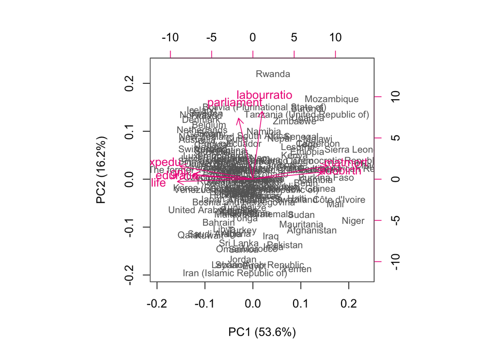

```r
pc_lab2 <-paste0(names(pca_pr2), " (", pca_pr2, "%)")


biplot(pca_human2, cex = c(0.8, 1), col = c("grey40", "deeppink2"), xlab = pc_lab2[1], ylab = pc_lab2[2])
```

Due to scaling, the results of the second analysis are quite different from the first one in which variable “gni” had a great importance because of its large scale compared to the other variables. In the second analysis, the variables have more equal loadings.

The first component (PC1) captures 53.6 % of the variance in the data. As the plot above shows, this component is highly loaded with variables indicating life expectancy, maternal mortality, adolescent birth rate, expected years of education and education ratio between genders. As for the second component (PC2), which captures 16.2 % of the variance, percentage of women in parliament and ratio of women to men in labour force have the greatest impact.

## Multiple correspondence analysis (MCA)

### Data

The data used in MCA exercise is the “the” dataset in R’s FactoMineR package, and it contains 300 observations and variables related to tea drinking habits. Out of the 36 variables in the original dataset, six are used in this exercise. The distributions of those are displayed in the summary matrix and the bar blot below.

```r
data("tea")
keep_columns <- c("sugar", "sex", "breakfast", "friends", "healthy", "feminine")
tea_time <- dplyr::select(tea, one_of(keep_columns))

summary(tea_time)
```

```
##       sugar     sex             breakfast          friends
##  No.sugar:155   F:178   breakfast    :144   friends    :196
##  sugar   :145   M:122   Not.breakfast:156   Not.friends:104
##         healthy            feminine
##  healthy    :210   feminine    :129
##  Not.healthy: 90   Not.feminine:171
```

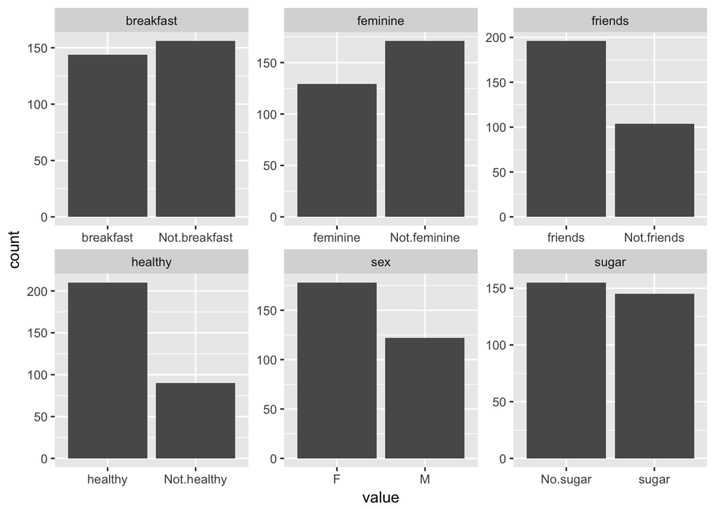

```r
gather(tea_time) %>% ggplot(aes(value)) + facet_wrap("key", scales = "free") + geom_bar()
```

### Analysis

Multiple correspondence analysis is run on the “tea_time” dataset with six variables. The results of the analysis can are displayed below, and the biplot visualizes the results.

```r
mca <- MCA(tea_time, graph = FALSE)
summary(mca)
```

```
##
## Call:
## MCA(X = tea_time, graph = FALSE)
##
##
## Eigenvalues
##                        Dim.1   Dim.2   Dim.3   Dim.4   Dim.5   Dim.6
## Variance               0.247   0.195   0.164   0.158   0.141   0.094
## % of var.             24.729  19.542  16.355  15.807  14.147   9.419
## Cumulative % of var.  24.729  44.271  60.626  76.433  90.581 100.000
##
## Individuals (the 10 first)
##                  Dim.1    ctr   cos2    Dim.2    ctr   cos2    Dim.3
## 1             |  0.727  0.713  0.475 | -0.606  0.626  0.330 |  0.241
## 2             | -0.121  0.020  0.015 | -0.765  0.998  0.608 |  0.241
## 3             | -0.270  0.098  0.103 |  0.112  0.021  0.018 | -0.381
## 4             |  0.682  0.626  0.428 | -0.055  0.005  0.003 |  0.382
## 5             |  0.624  0.525  0.277 | -0.387  0.256  0.107 |  0.504
## 6             |  0.385  0.200  0.140 | -0.308  0.161  0.089 |  0.349
## 7             |  0.328  0.145  0.125 | -0.533  0.485  0.328 | -0.553
## 8             | -0.663  0.593  0.427 | -0.120  0.025  0.014 |  0.597
## 9             |  0.624  0.525  0.277 | -0.387  0.256  0.107 |  0.504
## 10            |  0.431  0.251  0.171 | -0.859  1.258  0.676 |  0.209
##                  ctr   cos2
## 1              0.119  0.052 |
## 2              0.119  0.061 |
## 3              0.295  0.204 |
## 4              0.297  0.134 |
## 5              0.518  0.181 |
## 6              0.249  0.115 |
## 7              0.623  0.354 |
## 8              0.727  0.346 |
## 9              0.518  0.181 |
## 10             0.089  0.040 |
##
## Categories (the 10 first)
##                   Dim.1     ctr    cos2  v.test     Dim.2     ctr    cos2
## No.sugar      |  -0.427   6.352   0.195  -7.636 |  -0.324   4.626   0.112
## sugar         |   0.457   6.790   0.195   7.636 |   0.346   4.945   0.112
## F             |  -0.670  17.969   0.656 -14.001 |   0.101   0.517   0.015
```

[output cut: 12 more lines]

```
## breakfast     -12.627 |  -0.177   1.529   0.029  -2.938 |
## Not.breakfast  12.627 |   0.163   1.412   0.029   2.938 |
## friends         7.106 |  -0.641  27.367   0.775 -15.219 |
## Not.friends    -7.106 |   1.208  51.576   0.775  15.219 |
## healthy        -9.905 |  -0.215   3.292   0.108  -5.674 |
## Not.healthy     9.905 |   0.501   7.682   0.108   5.674 |
##
## Categorical variables (eta2)
##                 Dim.1 Dim.2 Dim.3
## sugar         | 0.195 0.112 0.002 |
## sex           | 0.656 0.015 0.001 |
## breakfast     | 0.005 0.533 0.029 |
## friends       | 0.021 0.169 0.775 |
## healthy       | 0.070 0.328 0.108 |
## feminine      | 0.537 0.015 0.067 |
```

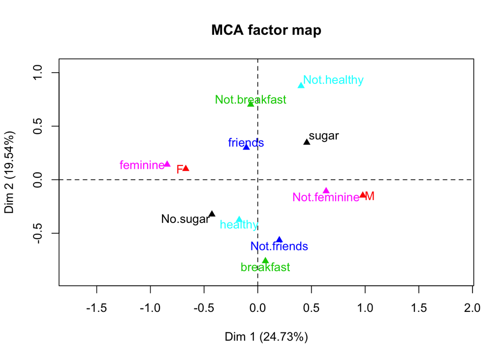

```r
plot(mca, invisible=c("ind"), habillage = "quali")
```

The first two dimensions produced by MCA capture 24.7 % and 19.5 % of the variance in the data. The first dimension is most highly linked to variables “sex”, “feminine” and “sugar” whereas the second dimension is linked to variables “breakfast”, “healthy” and “friends”.

As for the biplot, it shows for example that being male and not considering tea drinking feminine are somewhat close to each other whereas drinking tea with breakfast and without friends are close to each other as well considering tea drinking healthy and drinking it without sugar (meanings of the variables are assumed as I could not find descriptions of them anywhere).